# Main

TASK: 1) execute exponential smoothing 2) execute linear regression 3) predict the price 9 steps ahead

Exponential smoothing is a rule of thumb technique for smoothing time series data using the exponential window function. Whereas in the simple moving average the past observations are weighted equally, exponential functions are used to assign exponentially decreasing weights over time. It is an easily learned and easily applied procedure for making some determination based on prior assumptions by the user, such as seasonality. Exponential smoothing is often used for analysis of time-series data.

Exponential smoothing is one of many window functions commonly applied to smooth data in signal processing, acting as low-pass filters to remove high-frequency noise. This method is preceded by Poisson's use of recursive exponential window functions in convolutions from the 19th century, as well as Kolmogorov and Zurbenko's use of recursive moving averages from their studies of turbulence in the 1940s.

The raw data sequence is often represented by x_t beginning at time t=0, and the output of the exponential smoothing algorithm is commonly written as s_t, which may be regarded as a best estimate of what the next value of x will be. When the sequence of observations begins at time t=0, the simplest form of exponential smoothing is given by the formulas:

\begin{align} s_0& = x_0\\ s_{t}& = \alpha x_{t-1} + (1-\alpha)s_{t-1},\ t>0 \end{align}

```python
import os

# Set working directory
os.chdir('D:\Final_Project_Panko')

import Class_StockPriceForecasting as spf

stock_price_file_path = 'D:/Final_Project_Panko/AAPLHistoricalQuotes.csv'
result_file_path = 'D:/Final_Project_Panko/Result.csv'
```

```python
# Constructor
apple_prices =  spf.StockPriceForecasting(stock_price_file_path)
```

```python
help(spf.StockPriceForecasting.saveFirstDates)
apple_prices.saveFirstDates(result_file_path)
```

```
Help on method saveFirstDates in module Class_StockPriceForecasting:

saveFirstDates(self, file_name) unbound Class_StockPriceForecasting.StockPriceForecasting method
    This fuction saves in file close prices of first trading days for 8 months
```

```
Help on method executeExponentialSmoothing in module Class_StockPriceForecasting:

executeExponentialSmoothing(self, file_name) unbound Class_StockPriceForecasting.StockPriceForecasting method
    The fuction reads stock prices from a file and executes exponential smoothing

Please enter alpha: 0.4
```

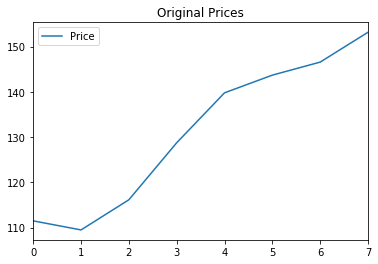

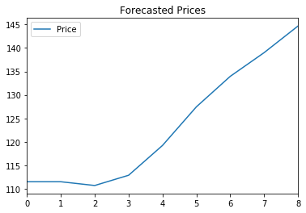

```
('Forecasted price is:', 144.67333824)
Do you want to change alpha?('y'/'n')'y'
Please enter alpha: 0.7
```

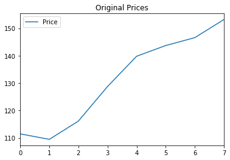

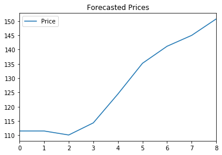

```
('Forecasted price is:', 150.71077026)
Do you want to change alpha?('y'/'n')'n'
Exponential smoothing successfully terminated
```

```python
help(spf.StockPriceForecasting.executeExponentialSmoothing)
apple_prices.executeExponentialSmoothing(result_file_path)
```

```python
help(spf.StockPriceForecasting.executeLinearRegression)
apple_prices.executeLinearRegression(result_file_path)
```

```
Help on method executeLinearRegression in module Class_StockPriceForecasting:

executeLinearRegression(self, file_name) unbound Class_StockPriceForecasting.StockPriceForecasting method
    The fuction reads stock prices from a file and executes linear regression

('original prices:', array([109.49, 116.15, 128.75, 139.79, 143.7 , 146.58, 153.18]))
('lag_prices:', array([111.49, 109.49, 116.15, 128.75, 139.79, 143.7 , 146.58]))
('mean original:', 133.9485714285714)
('mean lag:', 127.99285714285713)
('original st. dev:', 15.121647140602706)
('lag st. dev:', 14.574416640406685)
('corr coeff:', 0.9527622197677231)
('Calculated Slope:', 0.9885359017582507)
('Build-in function Slope:', 0.9885359017582496)
('Calculated Intercept:', 7.423036974242166)
('Build-in function Intercept:', 7.423036974242308)
('forecasted_price 9 time period:', 158.846966405571)
```

```python
try:
    file = open(result_file_path, 'a')
except IOError:
    print("Error during the file opening")
else:
    file.write('The Financial Statement Data Sets filed after 5:30PM Eastern on the last business day of a quarter\n')
    file.write('The first days for each month reflect information represented in month/quarter/anual financial statement\n')
    file.write('These days as a rule stock prices change more significantly and set new price level\n')
    file.write('Apple Inc. provides regular quarter financial statements has long history high trading volume and the stock price is relatively stable\n')
    file.close()
```